# googleplaydataset

Chen Ning Kuan

2020年1月27日

# 1.變數介紹:

我們有13個變數，包含10841個樣本

- App:Application name
- Category:Category the app belongs to
- Rating:Overall user rating of the app (as when scraped)
- Reviews:Number of user reviews for the app (as when scraped)
- Size:Size of the app (as when scraped)
- Installs:Number of user downloads/installs for the app (as when scraped)
- Type:Paid or Free
- Price:Price of the app (as when scraped)
- Content Rating:Age group the app is targeted at - Children / Mature 21+ / Adult
- Genres:An app can belong to multiple genres (apart from its main category). For eg, a musical family game will belong to Music, Game, Family genres.
- Last UpdatedDate: when the app was last updated on Play Store (as when scraped)
- Current VerCurrent: version of the app available on Play Store (as when scraped)
- Android Ver:Min required Android version (as when scraped)

# 2.資料處理方式

## 2.1刪掉的變數

我們刪掉 App,Last UpdatedDate,Current VerCurrent,Android Ver這4個變數

## 2.2變數處理方式

- 將Size變數全部轉成MB大小，並且刪除Size變數中 大小隨裝置改變的APP樣本去除
- 將Installs變數的“+”號去除
- 將Rating變數NA的樣本去除
- 新增一個變數叫做small app ，容量小於1MB的叫做small app

最後剩下7729個樣本和10個變數

# 3.感興趣的問題

## 3.1哪些因素會影響APP的訂價

這裡我們配適Tobit model中的corner soution 模型，以Price作為outcome，以Review,Rating,Installs,size_mb,small_app作為feature ，這裡使用Tobit model是因為Price有很多價格都等於0

note: 這裡我是參考別人配適婚外情的data，我不太確定left cersored在0是不是就等價 Tobit model中的corner soution

```r
fm.tobit <- tobit(Price ~Reviews+Rating+Installs+size_mb+small_app,
data = datause2)

summary(fm.tobit)
```

```
##
## Call:
## tobit(formula = Price ~ Reviews + Rating + Installs + size_mb +
##     small_app, data = datause2)
##
## Observations:
##          Total  Left-censored     Uncensored Right-censored
##           7729           7150            579              0
##
## Coefficients:
##                  Estimate    Std. Error z value             Pr(>|z|)
## (Intercept) -148.91289953   13.84169619 -10.758 < 0.0000000000000002 ***
## Reviews        0.00012537    0.00001232  10.176 < 0.0000000000000002 ***
## Rating        11.95001211    3.03144860   3.942           0.00008080 ***
## Installs      -0.00005735    0.00000531 -10.801 < 0.0000000000000002 ***
## size_mb        0.27169760    0.08312430   3.269              0.00108 **
## small_app     32.62328616    7.25582737   4.496           0.00000692 ***
## Log(scale)     4.30739311    0.03168942 135.925 < 0.0000000000000002 ***
## ---
## Signif. codes:  0 '***' 0.001 '**' 0.01 '*' 0.05 '.' 0.1 ' ' 1
##
## Scale: 74.25
##
## Gaussian distribution
## Number of Newton-Raphson Iterations: 11
## Log-likelihood: -4333 on 7 Df
## Wald-statistic: 142.4 on 5 Df, p-value: < 0.000000000000000222
```

## 3.2哪些因素會影響APP的Rating

```r
set.seed(1)
rf2<- ranger(Rating~Reviews+Installs+size_mb+small_app+Price+Type+Category+Genres+Content_Rating ,datause2, quantreg = TRUE,importance='impurity')
```

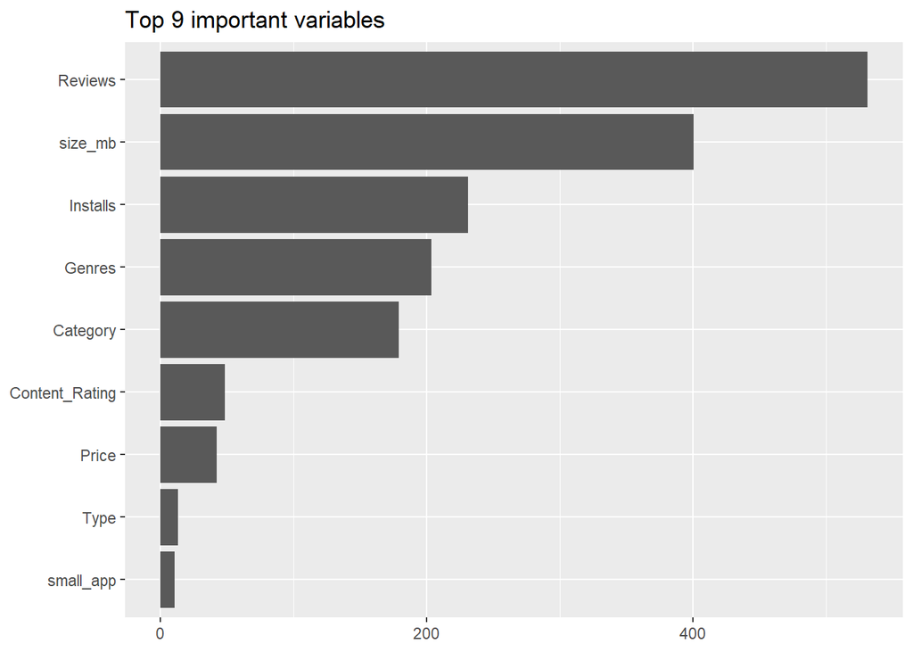

```r
rf2$variable.importance %>%
  as.matrix() %>%
  as.data.frame() %>%
  add_rownames() %>%
  `colnames<-`(c("varname","imp")) %>%
  arrange(desc(imp)) %>%
  top_n(25,wt = imp) %>%
  ggplot(mapping = aes(x = reorder(varname, imp), y = imp)) +
  geom_col() +
  coord_flip() +
  ggtitle(label = "Top 9 important variables") +
  theme(
    axis.title = element_blank()
  )
```

```r
df_numeric<- datause2
df_numeric[,11] <- ifelse(df_numeric$Price>0,1,0  )

df_numeric
```

```
## # A tibble: 7,729 x 11
##    Category Rating Reviews Installs Type  Price Content_Rating Genres size_mb
##    <fct>     <dbl>   <dbl>    <dbl> <fct> <dbl> <fct>          <fct>    <dbl>
##  1 ART_AND~    4.1     159    10000 Free      0 Everyone       Art &~    19
##  2 ART_AND~    3.9     967   500000 Free      0 Everyone       Art &~    14
##  3 ART_AND~    4.7   87510  5000000 Free      0 Everyone       Art &~     8.7
##  4 ART_AND~    4.5  215644 50000000 Free      0 Teen           Art &~    25
##  5 ART_AND~    4.3     967   100000 Free      0 Everyone       Art &~     2.8
##  6 ART_AND~    4.4     167    50000 Free      0 Everyone       Art &~     5.6
##  7 ART_AND~    3.8     178    50000 Free      0 Everyone       Art &~    19
##  8 ART_AND~    4.1   36815  1000000 Free      0 Everyone       Art &~    29
##  9 ART_AND~    4.4   13791  1000000 Free      0 Everyone       Art &~    33
## 10 ART_AND~    4.7     121    10000 Free      0 Everyone       Art &~     3.1
## # ... with 7,719 more rows, and 2 more variables: small_app <dbl>, V11 <dbl>
```

```r
df_numeric<-
df_numeric %>% rename(paidornot=V11)
df_numeric <- df_numeric[,-c(1,5,7,8)]
```

```r
#require(e1071)
#library(rminer)

#M <- fit(Price ~., data=df_numeric, model="svm", kpar=list(sigma=0.10))
#summary(M)
#svm.imp <- Importance(M, data=df_numeric)

sum(is.na.data.frame(df_numeric))
```

```
## [1] 0
```

```r
#model<-svm(Price ~ . , df_numeric)
#summary(model)

#model$SV
#svr.pred = predict(model, df_numeric)

#sqrt(  mean((df_numeric$Price - svr.pred)^2 ))
```

## 3.3針對price做預測

```r
require(e1071)
model <- lm(Price~.,df_numeric)
lm.pred = predict(model, df_numeric)
sqrt(  mean((df_numeric$Price - lm.pred)^2 ))
```

```
## [1] 16.92995
```

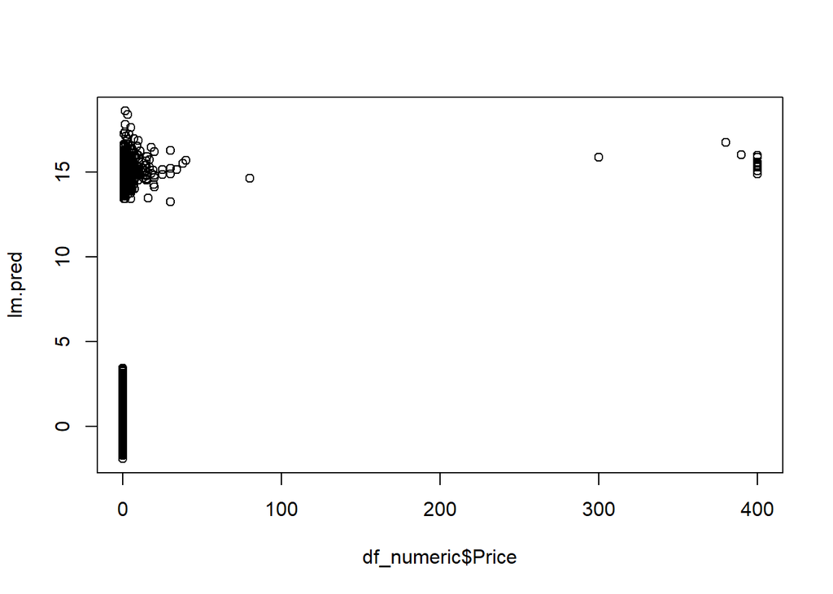

```r
plot(df_numeric$Price,lm.pred      )
```

```r
model2<-svm(Price ~ . , df_numeric)
summary(model)
```

```
##
## Call:
## lm(formula = Price ~ ., data = df_numeric)
##
## Residuals:
##    Min     1Q Median     3Q    Max
## -17.12  -0.43   0.00   0.37 385.08
##
## Coefficients:
##                     Estimate       Std. Error t value             Pr(>|t|)
## (Intercept)  4.4220948800543  1.5009652230536   2.946              0.00323 **
## Rating      -0.9694859078844  0.3565536818036  -2.719              0.00656 **
## Reviews      0.0000000634848  0.0000001350393   0.470              0.63828
## Installs     0.0000000001531  0.0000000049312   0.031              0.97523
## size_mb     -0.0157995417327  0.0086172007582  -1.833              0.06677 .
## small_app   -1.3010710291208  1.0954177462113  -1.188              0.23497
## paidornot   15.1931425351991  0.7364019535454  20.632 < 0.0000000000000002 ***
## ---
## Signif. codes:  0 '***' 0.001 '**' 0.01 '*' 0.05 '.' 0.1 ' ' 1
##
## Residual standard error: 16.94 on 7722 degrees of freedom
## Multiple R-squared:  0.05332,    Adjusted R-squared:  0.05258
## F-statistic: 72.48 on 6 and 7722 DF,  p-value: < 0.00000000000000022
```

```r
svr.pred = predict(model2, df_numeric)
sqrt(  mean((df_numeric$Price - svr.pred)^2 ))
```

```
## [1] 17.29564
```

## 3.4針對Rating做預測

```r
model <- lm(Rating~.,df_numeric)
lm.pred = predict(model, df_numeric)
sqrt(  mean((df_numeric$Rating - lm.pred)^2 ))
```

```
## [1] 0.5400799
```

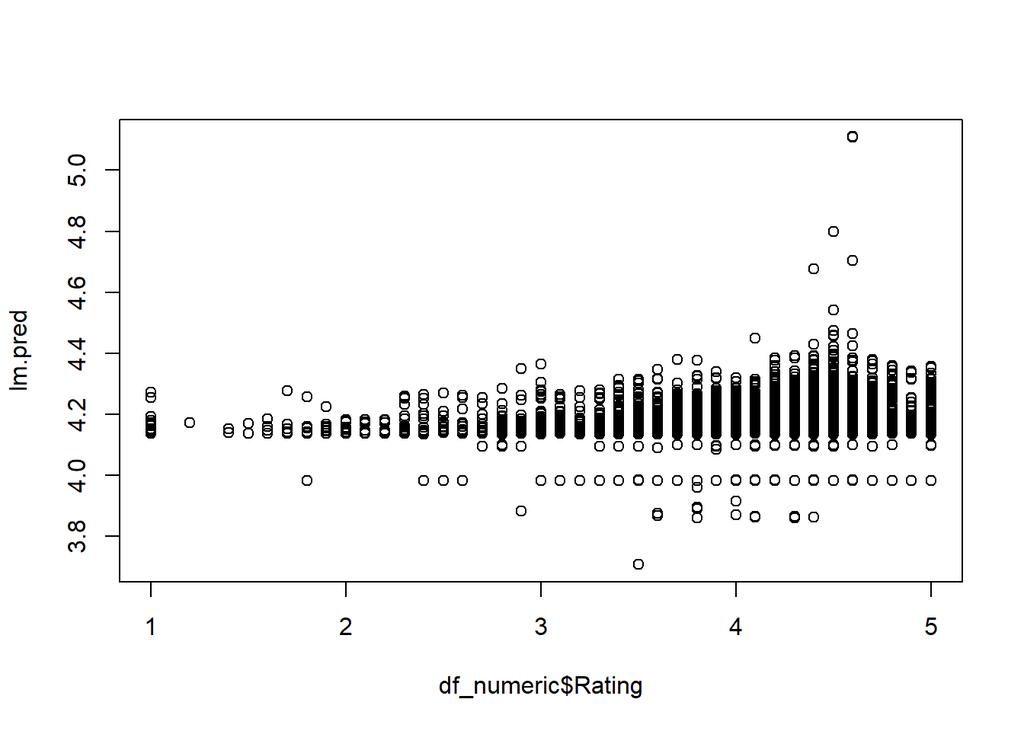

```r
plot( df_numeric$Rating,lm.pred      )
```

```r
model2<-svm(Rating ~ . , df_numeric)
summary(model)
```

```
##
## Call:
## lm(formula = Rating ~ ., data = df_numeric)
##
## Residuals:
##     Min      1Q  Median      3Q     Max
## -3.2715 -0.1806  0.0950  0.3374  1.0192
##
## Coefficients:
##                      Estimate        Std. Error t value             Pr(>|t|)
## (Intercept)  4.13355798059408  0.00908803462267 454.835 < 0.0000000000000002
## Reviews      0.00000001863717  0.00000000430271   4.331          0.000014997
## Installs     0.00000000004319  0.00000000015731   0.275              0.78366
## Price       -0.00098661167093  0.00036285212701  -2.719              0.00656
## size_mb      0.00138321739231  0.00027450499862   5.039          0.000000479
## small_app   -0.15283634103311  0.03490465336934  -4.379          0.000012097
## paidornot    0.11877477324580  0.02409276009006   4.930          0.000000840
##
## (Intercept) ***
## Reviews     ***
## Installs
## Price       **
## size_mb     ***
## small_app   ***
## paidornot   ***
## ---
## Signif. codes:  0 '***' 0.001 '**' 0.01 '*' 0.05 '.' 0.1 ' ' 1
##
## Residual standard error: 0.5403 on 7722 degrees of freedom
## Multiple R-squared:  0.01627,    Adjusted R-squared:  0.0155
## F-statistic: 21.28 on 6 and 7722 DF,  p-value: < 0.00000000000000022
```

```r
svr.pred = predict(model2, df_numeric)
sqrt(  mean((df_numeric$Rating - svr.pred)^2 ))
```

```
## [1] 0.5442792
```

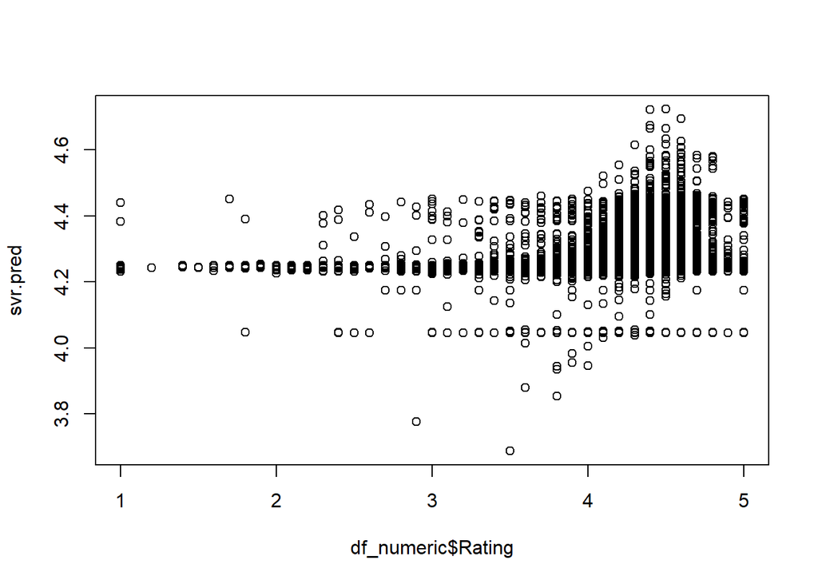

```r
plot( df_numeric$Rating,svr.pred      )
```